# TF array activity plotting (gcf6715)

Max Trauernicht

Netherlands Cancer Institute - van Steensel lab  
m.trauernicht@nki.nl

17/02/2022

### Aim

I received sequencing data from TF arrays that consist of 5 different TF reporters. I want to analyze here if the measured barcode counts make any sense.

## Setup

### Import sequencing data

```r
# Import barcode counts per condition - gcf6413
bc_files = list.files('/DATA/usr/m.trauernicht/projects/TF_array/data/gcf6715_TF_array_integrated/results/',
                       full.names=T, patter='*_counts.tsv')
bc_list <- lapply(bc_files, fread, header = FALSE)
names(bc_list)<- gsub('.*//6715_[0-9]{1,2}_(.*?)_[CGAT]{6}.*_counts.tsv',
                                    '\\1',
                                    bc_files)


# Import barcode annotation
bc_annotation <- read.csv2("/DATA/usr/m.trauernicht/projects/TF_array/data/gcf6413_TFarrayseq/TF_barcode_association.csv")
```

### Organize sequencing data

```r
# Generate long dfs
for (i in 1:length(bc_list)) {
  if (i == 1) {
  bc_df <- data.frame(bc_list[i])
  bc_df[3] <- names(bc_list[i])
  names(bc_df) <- c("barcode", "count", "name")
  bc_df <- reshape2::dcast(bc_df, barcode ~ name, value.var = "count")
  }
  else {
  bc_df_i <- data.frame(bc_list[i])
  bc_df_i[3] <- names(bc_list[i])
  names(bc_df_i) <- c("barcode", "count", "name")
  bc_df_i <- reshape2::dcast(bc_df_i, barcode ~ name, value.var = "count")
  bc_df <- merge(bc_df, bc_df_i, all = T)
  }
}

# Only keep designed barcodes
bc_df <- bc_df[bc_df$barcode %in% bc_annotation$barcode,]

# Add TF data
bc_df <- merge(bc_df, bc_annotation)


# Convert to long df
bc_df_long <- melt(bc_df, id.vars = c("barcode", "TF"),
              variable.name = "condition", value.name = "counts", as.is = T)
# Compute reads per million to estimate the relative counts in their respective sample
for (i in unique(bc_df_long$condition)) {
  bc_df_long$rpm[bc_df_long$condition == i] <- bc_df_long$counts[bc_df_long$condition == i]  / # Pseudocount not needed here
    (sum(bc_df_long$counts[bc_df_long$condition == i]) / 1e6)
}

# Normalize counts by dividing by pDNA counts
bc_df_long$plasmid <- gsub("(^[2-4]{2})_.*", "pMT\\1", bc_df_long$condition)
bc_df_long$condition <- gsub("^[2-4]{2}_(.*)", "\\1", bc_df_long$condition)


background <- bc_df_long %>%
  filter(TF == "Random") %>%
  dplyr::select(plasmid, condition, 'background' = rpm) %>%
  mutate(background = ave(background, condition, plasmid, FUN = function(x) mean(x))) %>%
  unique()

bc_df_long <- merge(bc_df_long, background, by = c("plasmid", "condition"), all = T)
bc_df_long$activity <- bc_df_long$rpm / bc_df_long$background

bc_df_long <- bc_df_long %>%
  dplyr::select(plasmid, TF, condition, activity, rpm) %>%
  unique()
```

## Reads per TF reporter

How active are the reporters (unnormalized)?

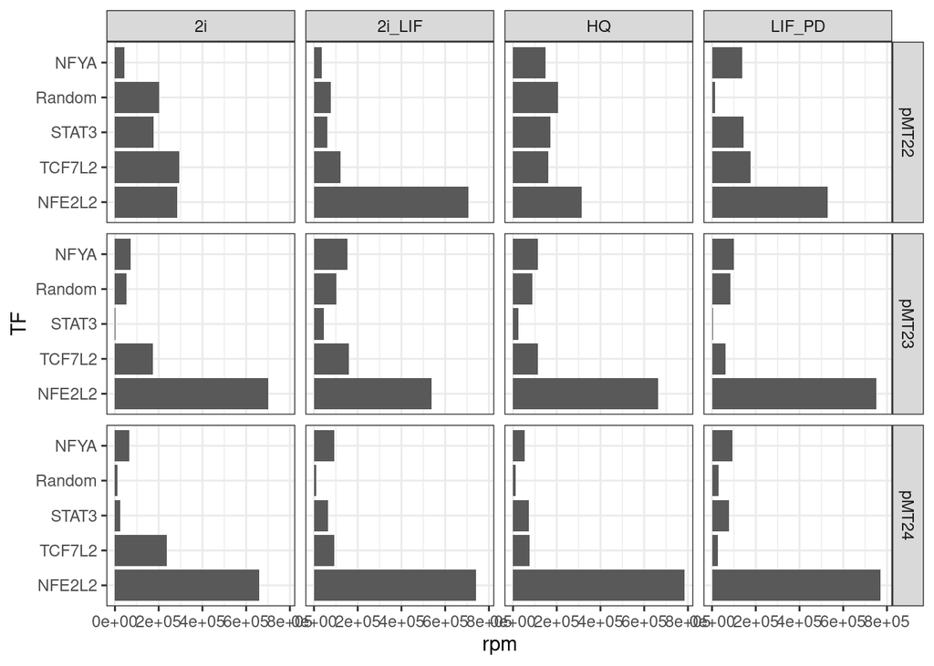

```r
# Plot all data
bc_df_long$TF <- factor(bc_df_long$TF, levels = c("NFE2L2", "TCF7L2", "STAT3", "Random", "NFYA"))

ggplot(bc_df_long,
       aes(x = TF, y = rpm)) +
  geom_bar(stat = "identity") +
  theme_bw() +
  facet_grid(plasmid ~ condition) +
  coord_flip()
```

Conclusion: pMT23 and pMT24 seem to give trustworthy activities. The random background is the lowest in pMT24 and specific activations make most sense in pMT24.

## Normalized activities of TF reporters

How active are the TF reporters per design compared to the negative control?

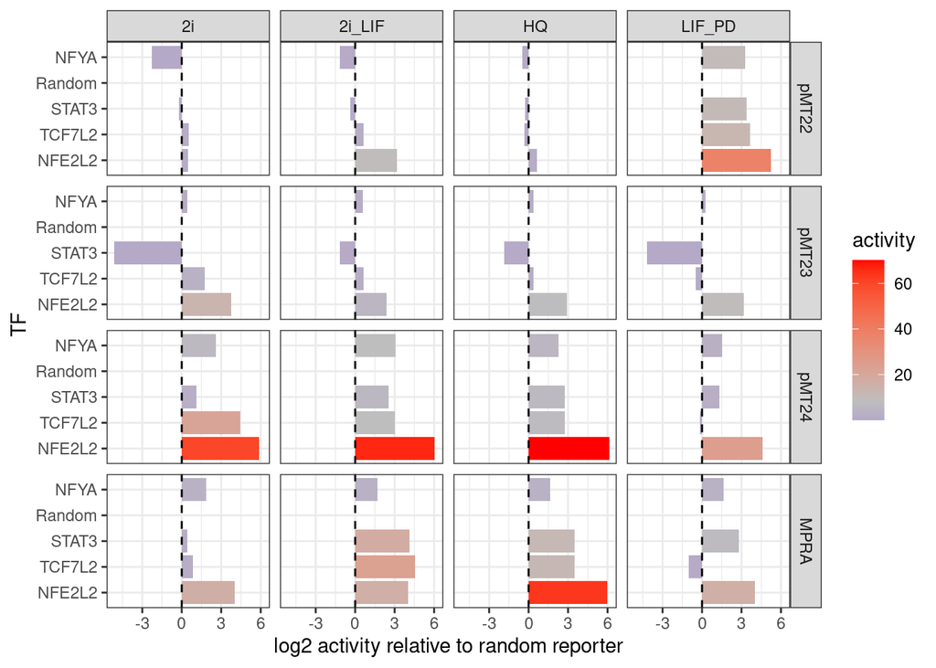

```r
# Include data from previous MPRA
# Specify the chosen reporters
selection_df <- data.frame(TF = c("Random1","Stat3","Tcf7l2","Nfya", "Nfe2l2"),
                           Spacing = c("5bp", "10bp", "5bp", "5bp", "5bp"),
                           Distance = c("10bp", "10bp", "10bp", "10bp", "10bp"),
                           Promoter = c("mCMV", "mCMV", "mCMV", "mCMV", "mCMV"),
                           Background = c("1", "3", "3", "2", "3"))
selection_df <- selection_df %>%
  mutate(reporter_id = paste(TF, Spacing, Distance, Promoter, Background, sep = "_"))


# Import MPRA data
cDNA_df <- read.csv("/DATA/usr/m.trauernicht/projects/SuRE-TF/data/gcf6139_stimulation-2/results/mt20201209_reporter_activity_filt.csv", header = T)
cDNA_df_1 <- read.csv("/DATA/usr/m.trauernicht/projects/SuRE-TF/data/gcf5927_stimulation-1/results/mt20201209_reporter_activity_filt.csv", header = T)
cDNA_df_1 <- cDNA_df_1 %>% setnames(c("background", "promoter",
                                      "spacing", "distance", "bc.number"),
                                    c("Background", "Promoter", "Spacing",
                                      "Distance", "Barcode"))
cDNA_df <- rbind(cDNA_df, cDNA_df_1)


cDNA_df_filt <- cDNA_df %>%
  mutate(reporter_id = paste(TF, Spacing, Distance, Promoter, Background, sep = "_")) %>%
  filter(reporter_id %in% selection_df$reporter_id,
         Barcode == 4) %>%
  dplyr::select(condition, TF, 'activity' = reporter_activity) %>%
  mutate(plasmid = "MPRA") %>%
  filter(condition %in% c("HQ", "2i_pos_LIF", "2i_neg_LIF", "LIF_pos_PD")) %>%
  unique()

cDNA_df_filt$condition[cDNA_df_filt$condition == "LIF_pos_PD"] <- "LIF_PD"
cDNA_df_filt$condition[cDNA_df_filt$condition == "2i_pos_LIF"] <- "2i_LIF"
cDNA_df_filt$condition[cDNA_df_filt$condition == "2i_neg_LIF"] <- "2i"
cDNA_df_filt$TF <- toupper(cDNA_df_filt$TF)
cDNA_df_filt$TF[cDNA_df_filt$TF == "RANDOM1"] <- "Random"


background <- cDNA_df_filt %>%
  filter(TF == "Random") %>%
  dplyr::select(plasmid, condition, 'background' = activity) %>%
  mutate(background = ave(background, condition, plasmid, FUN = function(x) mean(x))) %>%
  unique()

cDNA_df_filt <- merge(cDNA_df_filt, background, all = T)
cDNA_df_filt$activity_norm <- cDNA_df_filt$activity / cDNA_df_filt$background

cDNA_df_filt <- cDNA_df_filt %>%
  dplyr::select(-background) %>%
  setnames("activity", "rpm") %>%
  setnames("activity_norm", "activity")

bc_df_long <- rbind(bc_df_long, cDNA_df_filt)

bc_df_long <- bc_df_long %>%
         mutate(condition = gsub("_r[1,2]$", "", condition),
                activity = ave(activity, condition, TF, plasmid, FUN = function(x) mean(x))) %>%
  dplyr::select(plasmid, TF, condition, activity) %>%
  #mutate(activity = log2(activity)) %>%
  unique()

bc_df_long$plasmid <- factor(bc_df_long$plasmid, levels = c("pMT22", "pMT23", "pMT24", "MPRA"))

ggplot(bc_df_long,
       aes(x = TF, y = log2(activity), fill = activity)) +
  geom_bar(stat = "identity") +
  theme_bw() +
  scale_fill_gradient2(midpoint = mean(bc_df_long$activity), low = "blue", mid = "grey",
                            high = "red", space = "Lab" ) +
  facet_grid(plasmid ~ condition) +
  geom_hline(yintercept = 0, linetype = "dashed") +
  ylab("log2 activity relative to random reporter") +
  coord_flip()
```

```r
mpra_df <- bc_df_long %>%
  filter(plasmid == "MPRA") %>%
  distinct(activity, condition, TF) %>%
  setnames("activity", "mpra_activity")

bc_df_long2 <- merge(bc_df_long, mpra_df) %>%
  filter(str_detect(plasmid, "MPRA", negate = T))
```

Conclusion: The pMT24 reporter activies seem to overlap the MPRA reporter activities surprisingly well, even though there are some differences. Can we characterize these differences better?

## Investigate differences between pMT24 and MPRA reporter activities

Which TFs are more active in pMT24/MPRA and what could be an explanation for this?

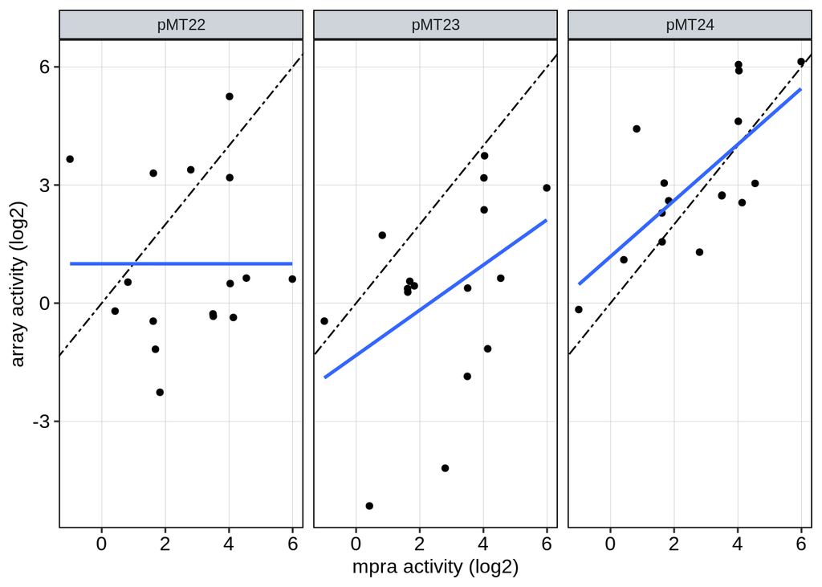

```r
ggplot(bc_df_long2 %>%
         filter(str_detect(TF, "Random", negate = T)),
       aes(x = log2(mpra_activity), y = log2(activity))) +
  geom_point() +
  geom_abline(lty = "twodash") +
  geom_smooth(method = "lm", se = F) +
  xlab("mpra activity (log2)") +
  ylab("array activity (log2)") +
  facet_grid(~plasmid)
```

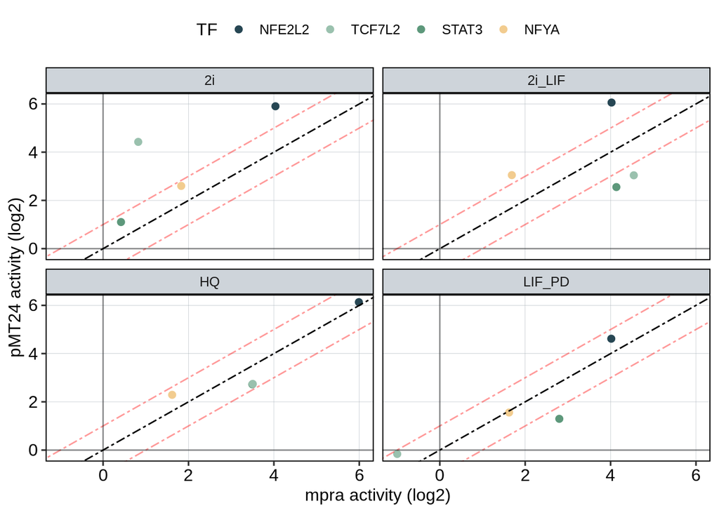

```r
ggplot_custom(bc_df_long2 %>%
                filter(plasmid == "pMT24") %>%
                filter(str_detect(TF, "Random", negate = T)),
       aes(x = log2(mpra_activity), y = log2(activity))) +
  #geom_smooth(method = "lm", se = F, color = "grey50") +
  geom_point(aes(color = TF), size = 2) +
  geom_abline(lty = "twodash") +
  geom_abline(lty = "twodash", intercept = 1, color = "red", alpha = 0.4) +
  geom_abline(lty = "twodash", intercept = -1, color = "red", alpha = 0.4) +
  geom_hline(yintercept = 0, alpha = 0.4) +
  geom_vline(xintercept = 0, alpha = 0.4) +
  xlab("mpra activity (log2)") +
  ylab("pMT24 activity (log2)") +
  facet_wrap(~condition)
```

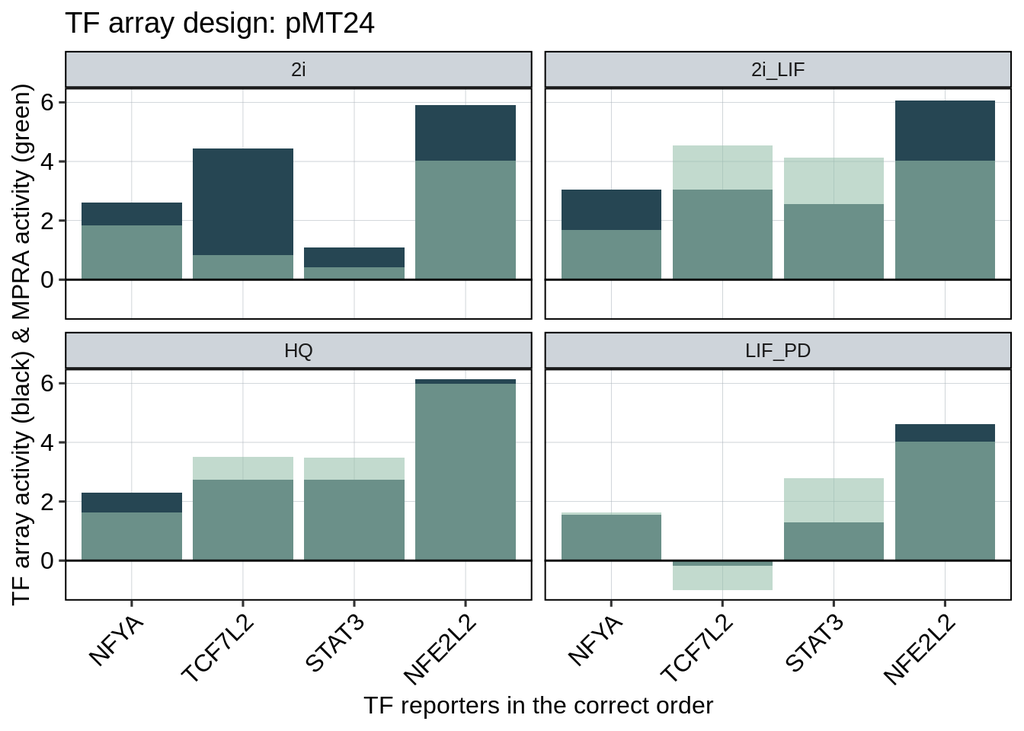

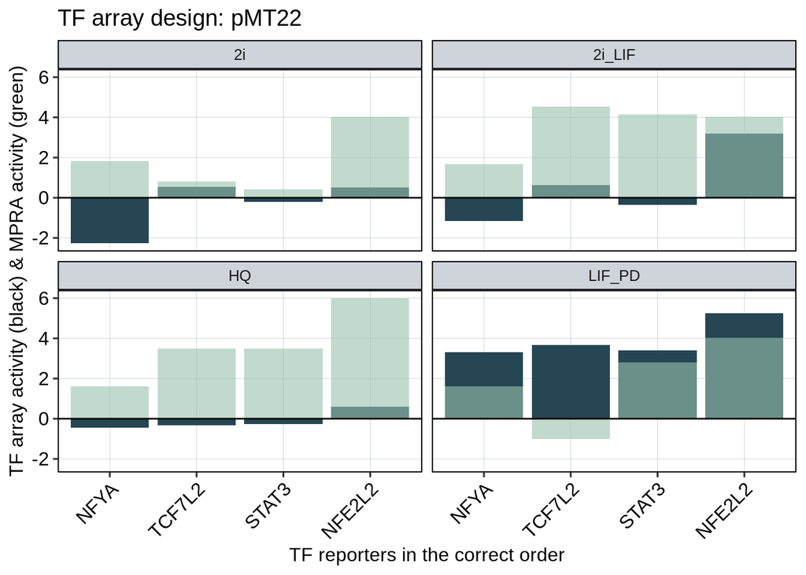

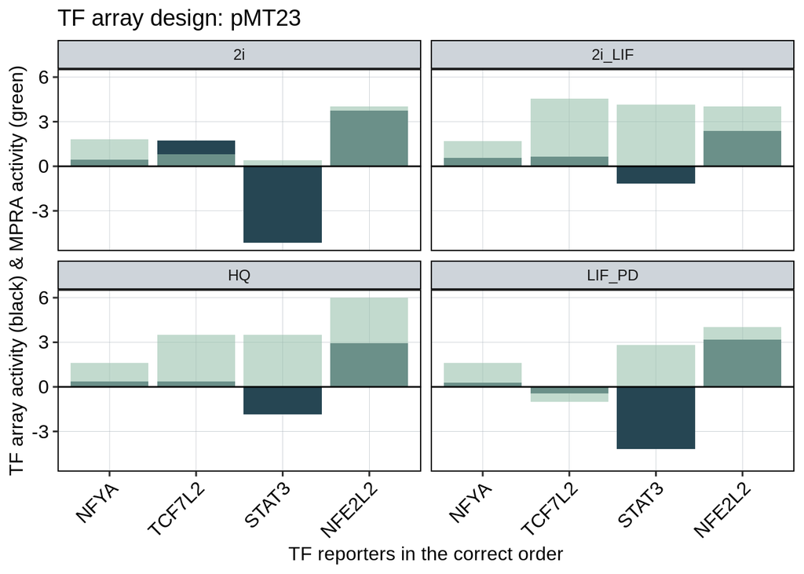

```r
# Explore differences between pMT24 and MPRA data
bc_df_long2$TF <- factor(bc_df_long2$TF, levels = c("NFYA", "Random", "TCF7L2", "STAT3", "NFE2L2"))

for (i in unique(bc_df_long2$plasmid)) {
  p <- ggplot(bc_df_long2 %>%
                filter(plasmid == i) %>%
         filter(str_detect(TF, "Random", negate = T))) +
  geom_bar(stat = "identity", aes(y = log2(activity), x = TF), fill = colors_diverse[1]) +
  geom_bar(stat = "identity", aes(y = log2(mpra_activity), x = TF), fill = colors_diverse[2], alpha = 0.6) +
  facet_wrap(~condition) +
  theme_classic_lines_45() +
  geom_hline(yintercept = 0) +
  xlab("TF reporters in the correct order") +
  ylab("TF array activity (black) & MPRA activity (green)") +
    ggtitle(paste("TF array design:", i))

  print(p)
}
```

Conclusion: There are still some (large) differences between the array and the MPRA reporter activities, but this is to some extent to be expected because of the different nature of the techniques. Integrated reporters might simply have a different reporter activity than plasmid reporters. The most intriguing differences are: 1) NFE2L2 is more active in pMT24 when unstimulated (2i and 2i+LIF) - why is this? Technical issue? 2) TCF7L2 is far more active in 2i in the genome. However, it is known that TCF7L2 is upregulated upon LIF removal (Dunn et al., 2014, Science) and loses its repressive action. I need to look into this more.

## Correlation between TIDE and sequencing

Can we use only TIDE to infer TF activity?

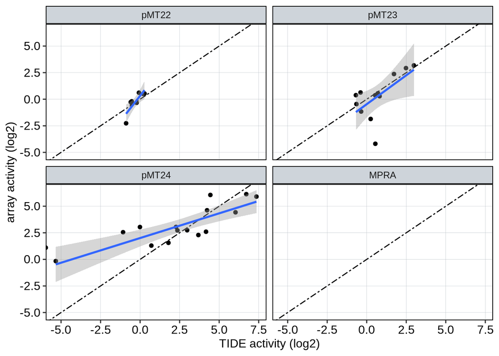

```r
# Include data from same cDNA quantified by TIDE
tide_activities <- read.csv2("/DATA/usr/m.trauernicht/projects/TF_array/data/TIDE/E1704_20211223/activity_summary.csv") %>%
  dplyr::select(condition, "tide_activity" = activity, TF) %>%
  filter(condition != "gDNA_ctrl") %>%
  mutate(plasmid = gsub("(^[2-4]{2})_.*", "pMT\\1", condition)) %>%
  mutate(condition = gsub("^[2-4]{2}_(.*)", "\\1", condition))

bc_df_long <- merge(bc_df_long, tide_activities, all = T)

random_tide <- bc_df_long %>%
  filter(TF == "Random") %>%
  dplyr::select(plasmid, condition, 'tide_random' = tide_activity) %>%
  na.omit()

bc_df_long <- merge(bc_df_long, random_tide, all = T) %>%
  mutate(tide_activity = as.numeric(tide_activity)) %>%
  mutate(tide_random = as.numeric(tide_random)) %>%
  mutate(tide_activity = tide_activity/tide_random) %>%
  dplyr::select(-tide_random)

ggplot(bc_df_long %>%
         filter(str_detect(TF, "Random", negate = T)),
       aes(x = log2(tide_activity), y = log2(activity))) +
  geom_point() +
  facet_wrap(~plasmid) +
  geom_abline(lty = "twodash") +
  geom_smooth(method = "lm") +
  xlab("TIDE activity (log2)") +
  ylab("array activity (log2)")
```

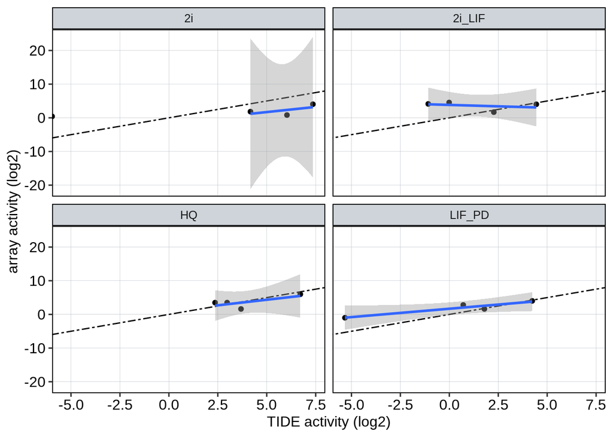

```r
# Correlation between TIDE activity (pMT24) and MPRA data
tide_df <- bc_df_long %>%
  filter(plasmid == "MPRA") %>%
  distinct(condition, TF, activity)

tide_activities_df <- bc_df_long %>%
  filter(plasmid == "pMT24") %>%
  distinct(condition, TF, tide_activity)

tide_activities_df <- merge(tide_activities_df, tide_df)

ggplot(tide_activities_df %>%
         filter(str_detect(TF, "Random", negate = T)),
       aes(x = log2(tide_activity), y = log2(activity))) +
  geom_point() +
  geom_abline(lty = "twodash") +
  geom_smooth(method = "lm") +
  xlab("TIDE activity (log2)") +
  ylab("array activity (log2)") +
  facet_wrap(~condition)
```

# Session Info

```r
paste("Run time: ",format(Sys.time()-StartTime))
```

```
## [1] "Run time:  19.07336 secs"
```

```r
getwd()
```

```
## [1] "/DATA/usr/m.trauernicht/projects/TF_array"
```

```r
date()
```

```
## [1] "Thu Feb 17 10:19:25 2022"
```